# Analiza YouTube scene u Hrvatskoj

Lux

28 06 2021

Društveni su mediji danas najvažniji izvor informacija o društvu i podloga su za sve važnije poslovne i političke odluke. U zadnje vrijeme primjetan je sve veći broj istraživanja koja se temelje na podatcima s društvenih medija, unatoč sveopćoj [APIkalipsi](https://www.tandfonline.com/doi/abs/10.1080/1369118X.2019.1637447) koja je tamo postala sveprisutna. “APIkalipsa” odnosno uvođenje restrikcija u strojnom pristupu podatcima s društvenih medija rezultat je Facebookove afere povezane s tvrtkom Cambridge Analytica koja je izvrsno opisana u dokumentarnom filmu [The social Dilemma](https://www.thesocialdilemma.com/).U istraživanjima društvenih medija YouTube platforma dugo je vremena bila zanemarena u usporedbi s Facebookom i Twitterom, no u zadnjih se nekoliko godina to počelo mijenjati kada su teme [političkog ekstremizma](https://dl.acm.org/doi/10.1145/3351095.3372879), [dezinformacija](https://firstmonday.org/article/view/10112/8332), [kulturne medijacije](https://www.sciencedirect.com/science/article/abs/pii/S0304422X16300973), [radikalizacije društva](https://www.nytimes.com/2018/03/10/opinion/sunday/youtube-politics-radical.html), [odnosa globalnih i lokalnih medijskih struktura](https://ijoc.org/index.php/ijoc/article/view/5725) te [nasilja nad djecom](https://medium.com/@jamesbridle/something-is-wrong-on-the-internet-c39c471271d2) počele dobivati na važnosti, a upravo je YouTube dobar izvor podataka za analizu tih fenomena.

Nadovezujući se na rastuću istraživačku popularnost YouTube platforme, u ovom ću postu dati opći pregled hrvatskoga YouTubea. Pregled se odnosi na osnovne značajke i uključuje: **1)** deskriptivni prikaz domaćih YouTube kanala, **2)** pregled kanala prema veličini i kategorijama te **3)** stratifikacijski pregled. Analiza je inspirirana nizom ([I](https://journals.sagepub.com/doi/10.1177/1354856517736979),[II](https://scholarspace.manoa.hawaii.edu/handle/10125/59701),[III](https://eprints.qut.edu.au/202962/1/View_of_Mapping_YouTube_First_Monday.pdf)) nedavno objavljenih radova koji analiziraju YouTube platformu na osnovi različitih podataka i na drugačiji način. Za ovaj su post korišteni podatci s oko (~)2 tisuće (k) hrvatskih YouTube kanala preuzeti sa [SOCIAL BLADE](https://socialblade.com/) i [ChannelCrawler](https://channelcrawler.com/). Podatci i `code` su “opensourceani”. u [repozitoriju](https://github.com/lusiki/Learning-Social-Media-Analytics) kolegija [Learning Social Media Analytics](https://lusiki.github.io/Learning-Social-Media-Analytics/) koji je u pripremi za 2021/22 godinu na [FHS](https://www.hrstud.unizg.hr/)(Fakultetu hrvatskih studija).

## Ponuda i potražnja za YouTube sadržajem u Hrvatskoj

ouTube je drugi najveći (nakon Facebooka) globalni društveni medij na svijetu s oko [2,9 mlrd korisnika](https://www.statista.com/statistics/272014/global-social-networks-ranked-by-number-of-users/) u 2021. godini, a [podatci](https://datareportal.com/reports/digital-2021-croatia?rq=Croatia) za Hrvatsku pokazuju da **potražnja** za YouTube sadržajem ima doseg od 2,8 mil stanovnika. Prema istim podatcima mjesečni je broj posjeta YouTube stranici u Hrvatskoj između 19 mil i 60 mil [^1], a broj jedinstvenih posjeta u rasponu od 1.99 mil do 2.65 mil [^2]. Pri tome prosječni YouTube posjetitelj provede otprilike 20 do 30 min na toj platformi, pregledavajući u prosjeku između 3 i 14 kanala. Visoka se popularnost platforme očituje u čestom *googlanju* riječi “YouTube” koja je na 14. mjestu i to odmah nakon najvećih domaćih novinskih i informativnih portala. Zanimljivo je da se YouTube platformi u Hrvatskoj najčešće pristupa na računalu ili laptopu, što nije tipično za ostale društvene medije kojima se uglavnom pristupa na mobilnim uređajima. Na kraju valja dodati i to da je YouTube publika relativno mlada. Više od polovine posjetitelja u dobnom je rasponu od 18 do 34 godine.

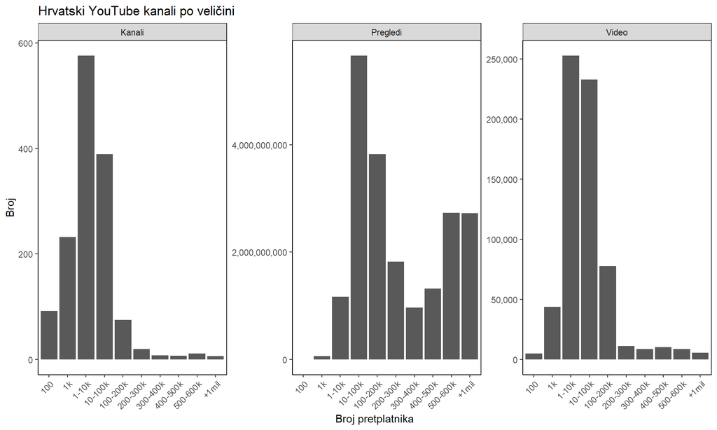

Na gornjem je grafikonu prikazan skupni pregled hrvatskih YouTube kanala po veličini, za tri kriterija: broj kanala, videa i pregleda. Prikaz upućuje na tri stvari: **1)** Bimodalnu distribuciju pregleda koja odražava potražnju za lokalnim sadržajem (na hrvatskom jeziku) budući da manji i lokalni kanali imaju puno lokalnih pretplatnika dok veći i globalnoj publici orijentirani kanali imaju puno stranih pretplatnika. Ovu pretpostavku nisam eksplicitno testirao na podatcima, ali pregled (“golim okom”) kanala u rasponu 10k-100k pretplatnika upućuje na takav zaključak, a postoje i dobri [dokazi](https://eprints.qut.edu.au/202962/1/View_of_Mapping_YouTube_First_Monday.pdf) o YouTube homofiliji (važnosti lokalno generiranog sadržaja); **2)** Spomenuta bimodalnost također ukazuje na to da broj pretplatnika kao kriterij za procjenu veličine i uspjeha kanala nije idealan jer manji odnosno srednje veliki kanali također mogu imati značajan broj pregleda. S druge je strane također očito da broj pregleda, koliko god bio nesavršen kao pokazatelj popularnosti, [ipak dobro određuje razinu popularnosti](https://www.youtube.com/watch?v=y9Hn9a1WC-0&t=101s). **3)** Manji kanali moraju proizvesti puno više (video) sadržaja za jednak ili manji broj pretplatnika i pregleda, što ukazuje na veliku konkurenciju, težak i trnovit put do YouTube uspjeha.

## Pregled najvažnijih kategorija

YouTube platforma, uz kopleksan [algoritamski ples](https://policyreview.info/articles/analysis/algorithmic-dance-youtubes-adpocalypse-and-gatekeeping-cultural-content-digital) s kreatorima sadržaja, tematski organizira kanale u sedam glavnih kategorija koje se, ne sasvim jasnom logikom, granaju u podkategorije. Glavne kategorije sa svojim podkategorijama su: *entertainment, gaming, lifestyle, music, society* i *sports*, dok sedma kategorija *knowledge* nema podkategorija. U ovoj analizi prikazano je nešto više kategorija jer su kanali tako označeni na podatcima za Hrvatsku. Razlog za to nije mi poznat, no pretpostavljam da je YouTube proizvoljno odlučio na taj način kategorizirati domaće kanale. Inače, kategorizacija YouTube kanala nije samo tehnička stvar nego je iznimno važna u internom monetizacijskom algoritmu platforme. Pri tome YouTube vrlo vješto koristi vlastiti kategorizacijski sustav kako bi promovirao odnosno “prikrio” manje poželjan sadržaj poput političkog, aktivističkog pa čak i edukativnog što je popraćeno i opravdanim [kritikama](https://journals.sagepub.com/doi/10.1177/1354856517736979).

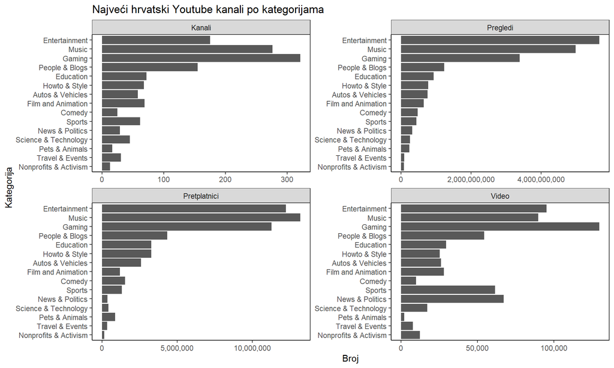

## Kategorije i veličina kanala

Nakon pregleda osnovnih karakteristika i kategorija YouTube kanala treba pogledati i njihov međusobni odnos. Za te potrebe pojednostavnit ću kategorizaciju kanala prema broju pretplatnika i nazvati sve kanale do 1k preptlatnika – “Bube”, od 1k do 10k – “Glodavci”, od 10k do 100k – “Sisavci”, a sve preko 100k – “Dinosauri”. Podatci prikazani u donjoj tablici jasno pokazuju (**agregatni**) nesrazmjer između dinosaura i nižih vrsta u svim metrikama. Dinosauri su malobrojni i na malo sadržaja ostvaruju najviše pretplatnika i pregleda. Daleko ispod Dinosaura nalaze se Sisavci i Glodavci koji na sličnoj količini sadržaja (broj videa) ostvaruju tek oko 30 % (Sisavci), odnosno 5 % (Glodavci) pretplatnika i pregleda Dinosaura. Na samom dnu su Bube koje imaju zanemariv broj pretplatnika i pregleda, ali pokazuju znatan YouTube entuzijazam kroz relativno velik broj kanala.

Agregatni pregled metrika prema veličini kanala

| Ranges | Kanali | Video | Pretplatnici | Pregledi |
| --- | --- | --- | --- | --- |
| Bube | 324 | 48.801 | 106.868 | 60.569.854 |
| Glodavci | 576 | 252.850 | 2.187.350 | 1.167.730.041 |
| Sisavci | 389 | 233.007 | 13.377.400 | 5.664.769.295 |
| Dinosauri | 127 | 121.584 | 40.770.000 | 13.397.196.000 |

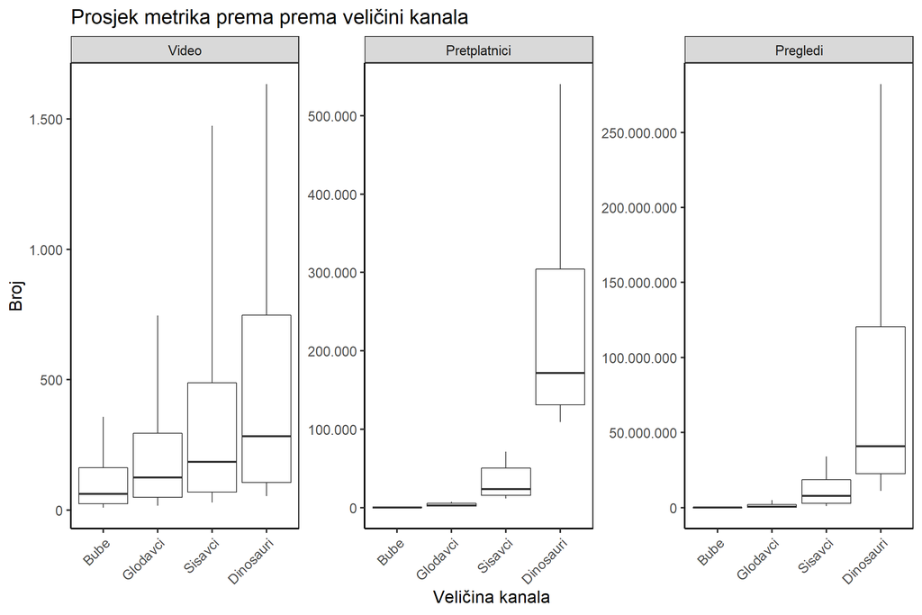

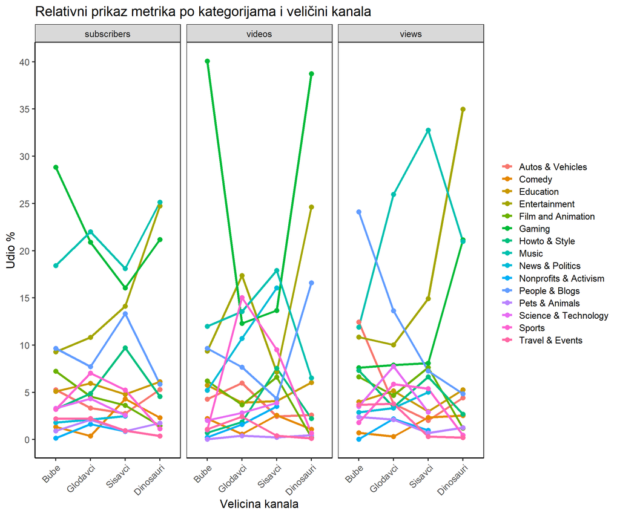

Na osnovi prethodnog pregleda hrvatske YouTube scene je moguće donijeti nekoliko glavnih zaključaka:

**Prvo**, hrvatski (i globalni) YouTube jest platforma na kojoj dominira mali broj velikih kanala. U toj skupini velikih dodatno se ističe još manja skupina *elitnih* kanala koji imaju preko 1 mil. pretplatnika i dodatno iskrivljuje distribuciju u korist veličine. Iako bi donošenje dubljih zaključaka o prirodi ove distribucije zahtijevalo detaljniju analizu, jasno je da hrvatski YouTube nije sinonim za *informacijsku demokratizaciju* već za masovni medij na kojem dominira mali broj veliih kanala.

**Drugo**, pregled najzastupljenijih kategorija među domaćim kanalima ukazuje na fokus YouTube platforme prema zabavnom sadržaju. Osim što edukativni, društveni i politički sadržaj znatno teže ulazi u monetizacijske kategorije, takav sadržaj zahtjeva mnogo više angažmana (videa) za jednak ili manji broj pretplatnika i/ili pogleda.

**Treće**,na osnovi jednostavnog deskriptivnog pregleda vidljiva je (kulturološka) dominacija engleskoga govornoga područja među najvećim i najuspješnijim domaćim kanalima, ali isto tako i visok interes za kanale specijalizirane za lokalno relevantne teme. Tu je moguće dodati i to da principi koji vrijede na globalnoj YouTube platformi uvelike vrijede i u Hrvatskoj.

**Četvrto**, ova analiza predstavlja tek deskriptivni pregled na razini kanala i kao takva može ponuditi zanimljive i korisne, ali ipak ograničene, uvide u strukturu i trendove na domaćoj YouTube sceni. Daljnja bi analiza zahtijevala detaljnije (meta)podatke na razini pojedinog videa potencijalno uključujući transkribirani tekst pogodan za analizu sadržaja, no to ostavljam za neku drugu priliku.

[^3]: Ovisno o izvoru [SEMRUSH](https://www.semrush.com/) ili [similarweb](https://www.similarweb.com/).  
[^4]: 2CELLOS (5.68mil), HAUSER (1.85mil), Doctor D.S. (1.75mil), KingsOfFailsShow (1.15mil), agadmator’s Chess Channel (1.11mil),BloodMaster (1.07mil)